# 2016 Candidates and Funding

Jamey McCabe

August 11, 2015

This Analysis pulls in and analyzes the 2016 Federal Election Commision (FEC) registered Campaign Committtees. as of August 2015. Note that the data to be viewed will focus largely on the amount of new money flowing into these committees in the first 2 quarters of 2016 which is what the 2016 FEC data contains so far. Definitions of the data that these Committees report can be found here: http://www.fec.gov/finance/disclosure/metadata/MetadataforCommitteeReportbyReportSummary.shtml#search=%22fil_fre%22

The FEC provides us files in CSV format but it needs to be cleaned up in terms of:  
* strange characters in the names of the committes  
* converting currency displayed #s (i.e. leading $) to actual #s that can be summed and sorted  
* display dates in computer based format (underlying numeric)  
* removal of obviously invalid values  
* change of committe names that are too long to be useful and ruin some graphics

With the data in a fairly clean format lets look at histograms of some of the more promising factors which may be useful to better understand the data.

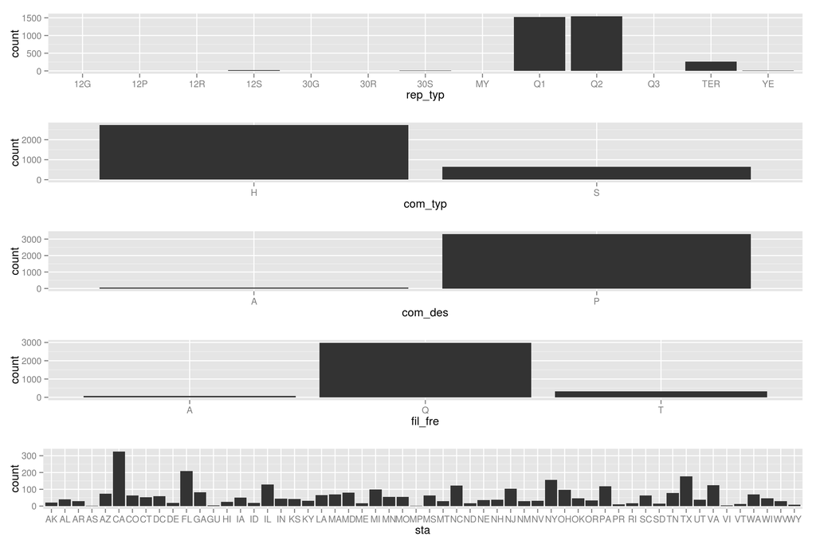

What we see in the above is  
# the top 2 factors, rep_type and com_typ look like useful factors for differentiating the data. For rep_type (Report Type) after further research it turns out this is really just telling us that the committes reported their income twice so far this year once in the first quarter and once in the second). Since we intend to do an analysis around income this is in essence a clue we have more vertical data and will need to summarize and is not a factor we will likely use to understand or model by.  
# second 2 factors (com_des and fil_fre) end up mostly unidemensional with most data being in 1 category. Usually not so useful in understanding the overall data.  
# sta - State - having a wide dispersion, this promises to be a great factor for looking at the population. in fact State calls for looking at the data in a color weighted map of the US.

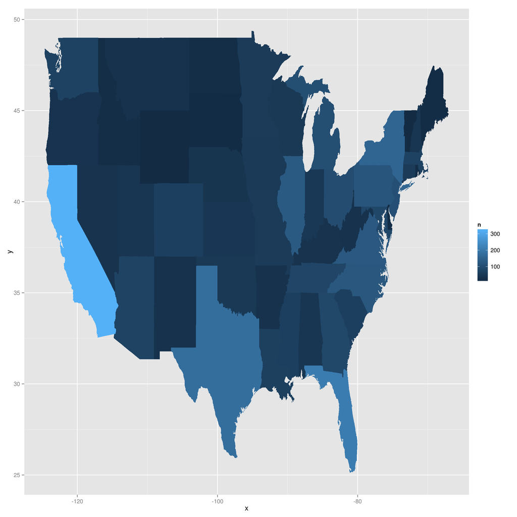

It’s more obvious from the US map that the most political committes are in California though also in Texas, Florida and New York. Not surprising as these are such large states. Not so obvious in the map but easier to see in the Histogram is that Illinois and North Carolina also have large #s of committees.  
So enough Uni-variate Analysis - lets start on some Bi-variate analysis using the tot_rec (Total Receipts) by State

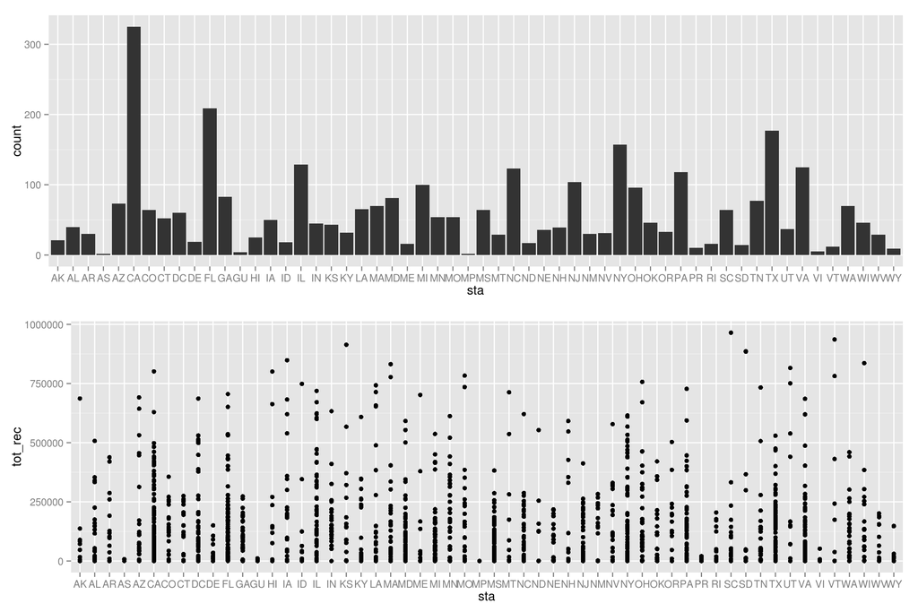

The above is comparing the numbers of committes in the bar graph to the individual committes receipts in the dot plot. it was expected to see larger #s of larger donations (dots high up) matching the larger states , namely California. This plot does not seem to show too many large donations and thelargest higher up grouping seem to be in Illinios and Texas. Perhaps a different scale might help - lets try a Log10 scale to better differentiate the larger groupings from the vast bulk at the bottom.

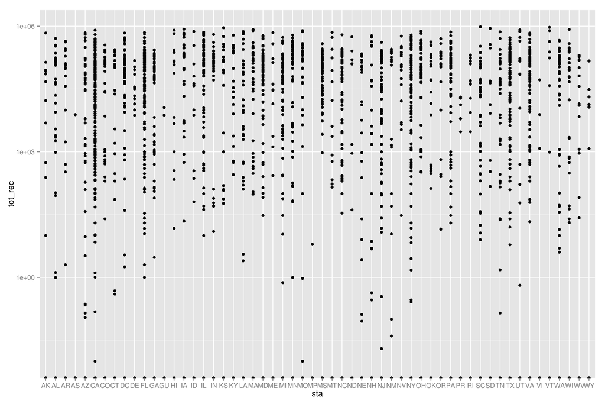

You can now see that California does a have a large # of larger donations. However, it’s hard to tell how dense they are with just the default black and white dot plot. Lets try out color and Alpha.

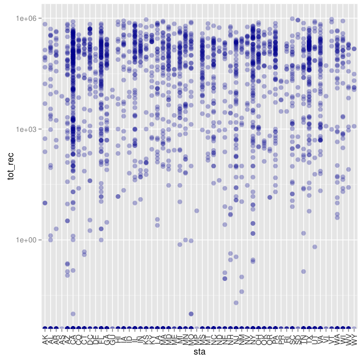

In the above you can nowmost clearly see the larger # of larger donations in california as well as Florida and Texas. Illinois also has a dense patter of very large donations but not so many midrange donations. The other now obvious feature of the data is the large amount of $0 receipts in the population. Those are the dots at the bottom. Apparently there are many committees with $0 receipts in this 6 month period.

Perhaps this would reveal more as a boxplot

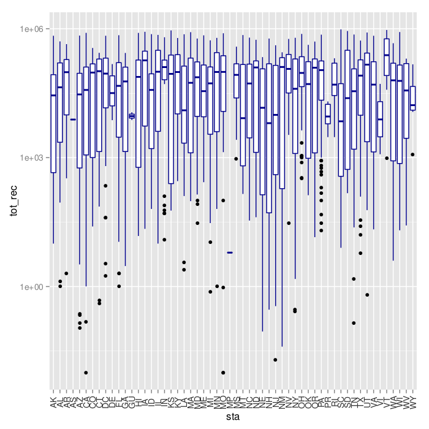

Lets move on to look at the distribution of the total receipts data not looking at what state they are from.

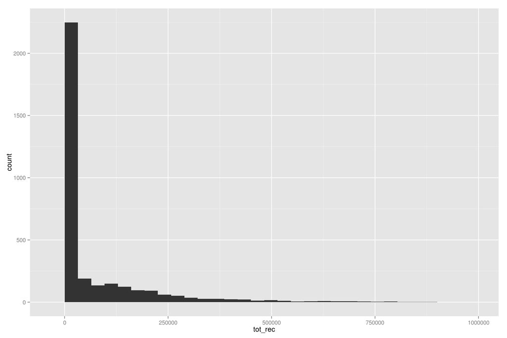

This is a very classic example of what is called long tail data - a large amount at one end (in this cae the $0 receipts) and fewer at the higher range - lets try log10 which oftern will reveal a more normal distribution curve (bell shaped distribution).

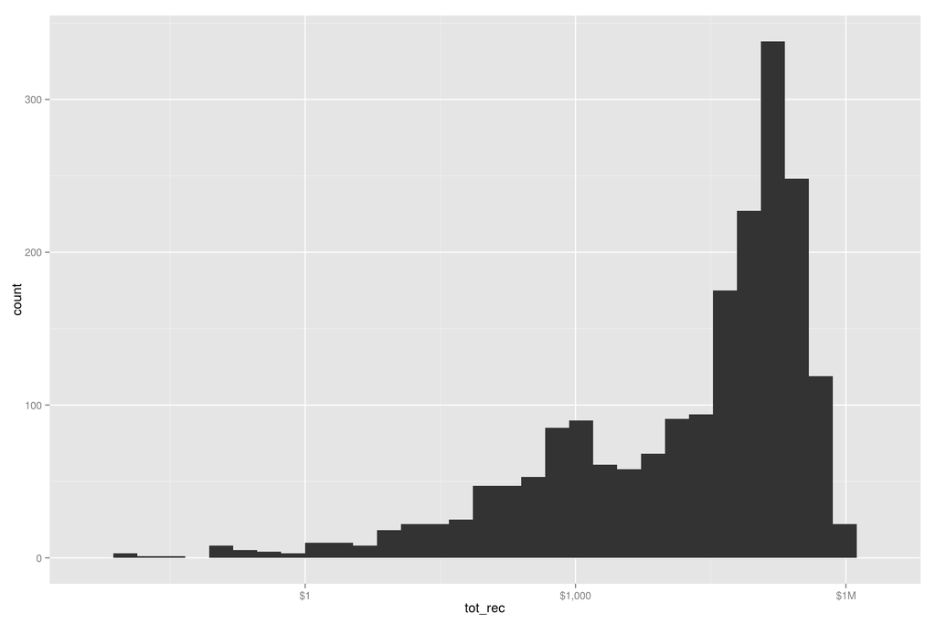

```
##    Min. 1st Qu.  Median    Mean 3rd Qu.    Max.
##       0       0     399   69310   86730  964800
```

So as seen earlier - a lot of committes with low receipts (the $0 receipts seen earlier) and the mean above the median which means that there are some very large data points bringing up the mean.  
As often talked about in recent election news perhaps there are just a few really large committees getting all the money. lets look further at the large ones.

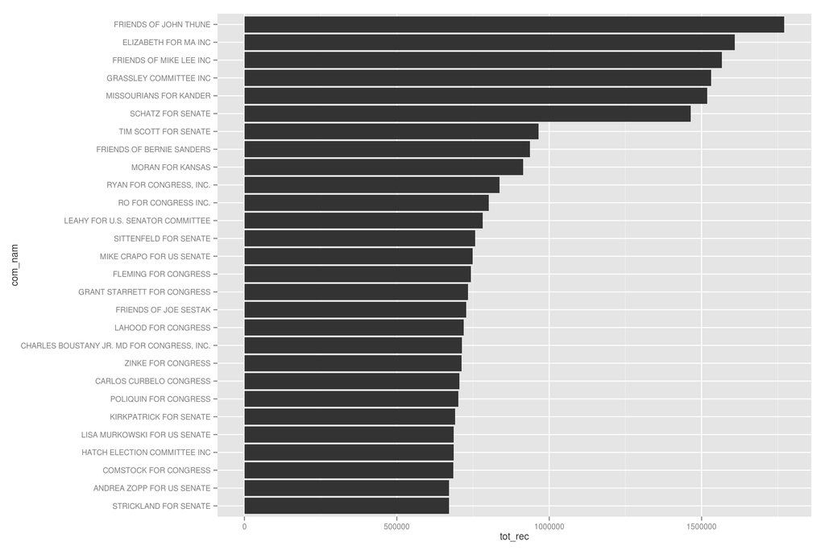

It’s interesting to see the real names of these committes and good to see the curve of how it declines from the maximum donation to the 99%. 995 is about 1/3 of the maximum. Lets see the curve for the top 5% even if we won’t see their names

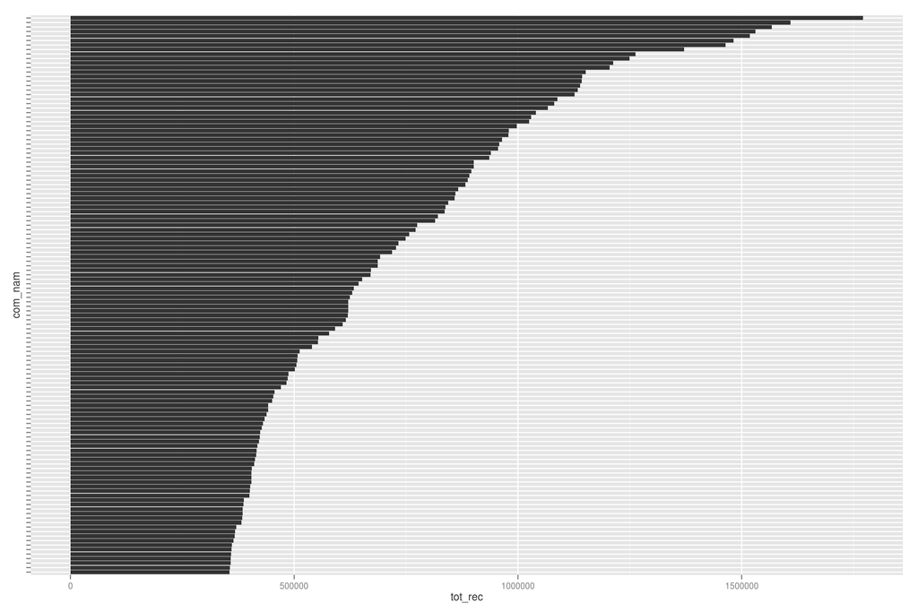

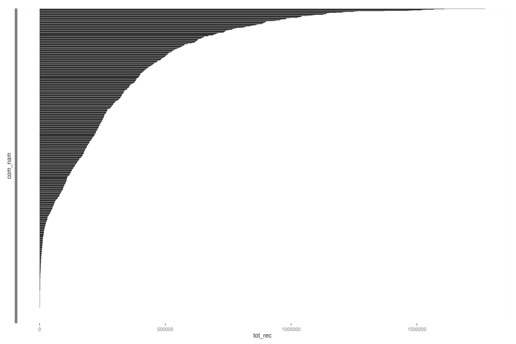

Yes it’s very cler to see here that there is a large area of committees adding the majority of all receipts below the 95%.  
Lets try some Multivariate Analysis concentrating on the 75%-95%. First lets summarize by all the factors in the data and a GGPAIRS analysis to se if there might be any correlations missed for the above analysis.

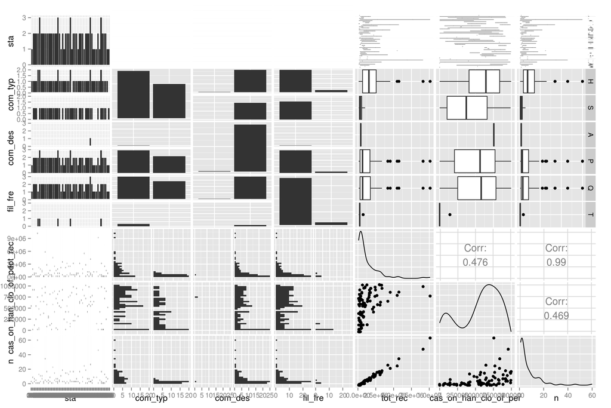

I’m interested in what the correlations are between tot_rec and cas_on_han and the other factors. Looking at the box plots at the intersection of cas_on_han and com_typ you can see a clear delineation showing that com_typ is associated with or driving different behavior in cas_on_hand. The graph and scale are small but seems a similar dilineation for tot_rec as well.  
Still hard to see it here, so lets just try them 1 by 1  
* com_typ = House versus Senate  
* com_des = Type of committe commitement to the candidate * fil_fre = filing Frequency

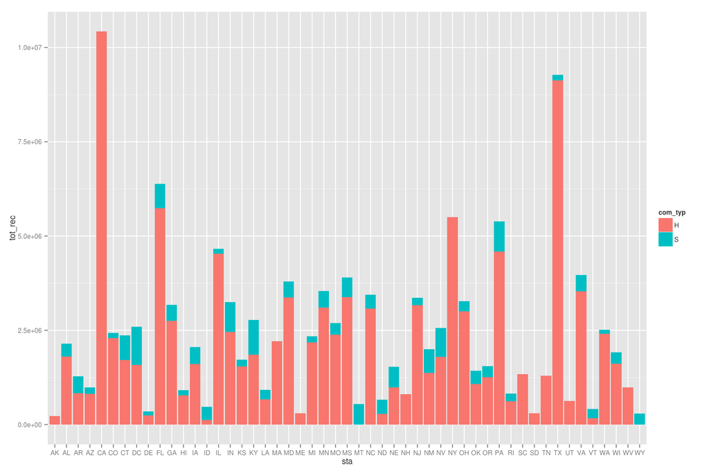

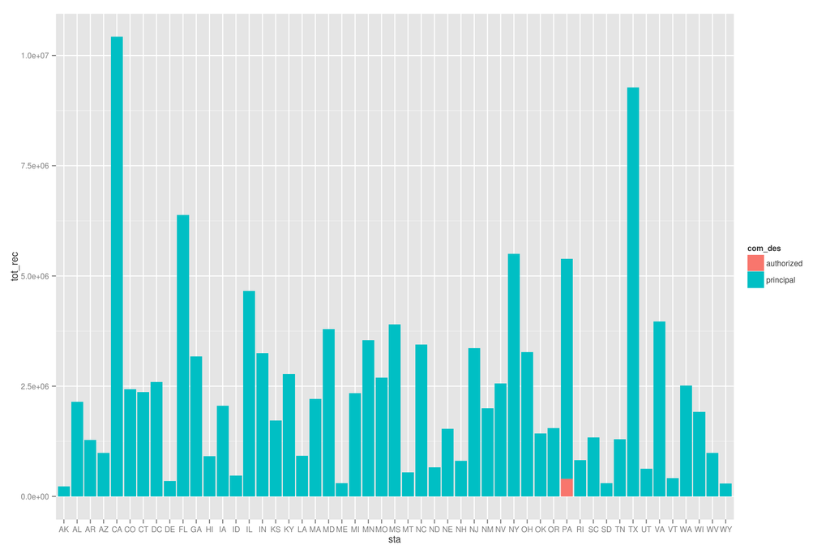

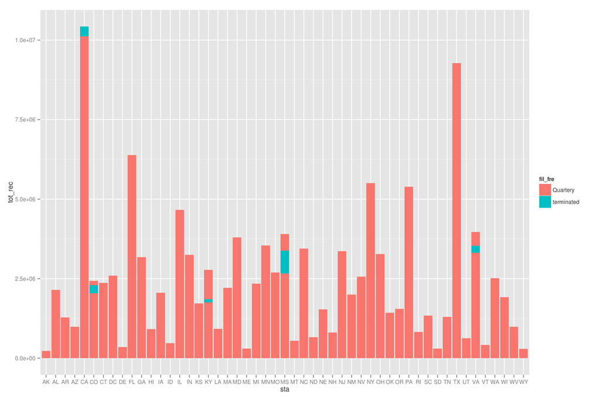

So it is really just Committee Type (House versus Senate) which is much of an interesting factor. Lets bring in Cash on Hand as a downward bar to compare to Total Receipts on the upward bar and use Committe Type as fill

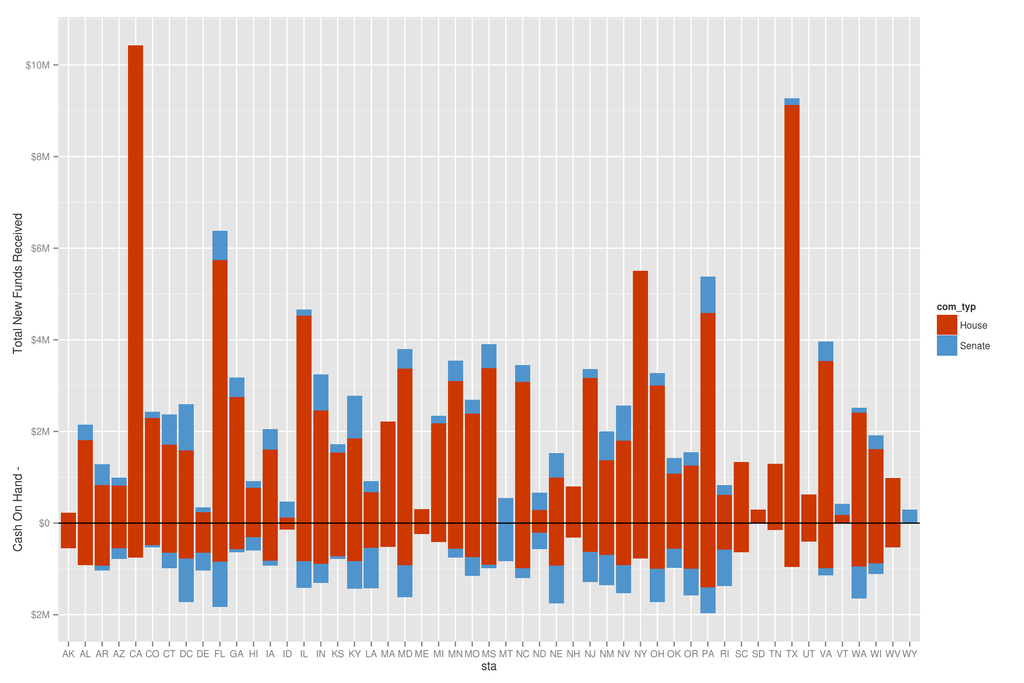

Yeah there is some intersting patterns.  
* Receipts (above the line) for the house(red ) are much higher than for the Senate (blue).  
* However Cash on hand (below the line) for Senate committes (blue ) is ofte equal to the house(red).  
I have no explanation for it just yet.

Lets try creating our own factor with Cut. Seems likely that there are natural groupings of committes based on how much money they’ve brought in. Lets try for 4 groups:  
1. Basically a bunch at the bottom (up to 75%) that bring in very little  
2.than a group 75% to 95% that don’t bring in so much but as there are a lot of them it adds up  
3&4. the bigs dogs in 2 more groups 95-99% and the top 1%ers.

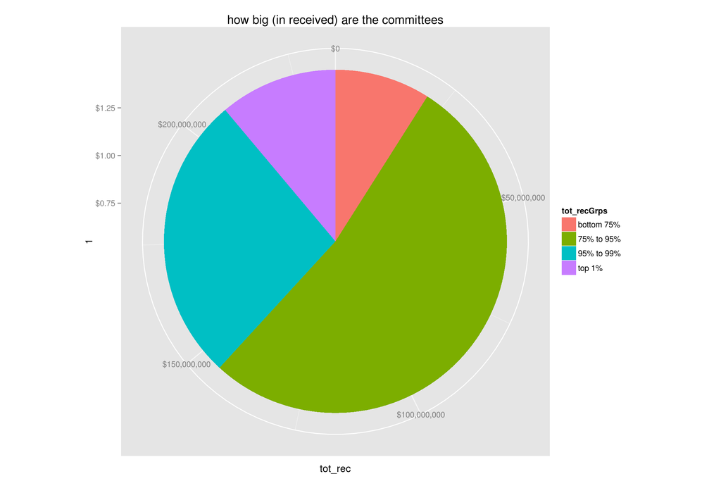

The above gives a nice picture of a new revelation about Polical Committees: most money is not coming from the big dogs but from the 20% of committes in the 75%to95% range.

Ok so lets conclude with 3 graphs of the most revealing information:

# 1 Top 5% of Committes and pattern of receipts for them.

Interesting to see the names and shows that the top 1% is in no way overshadowing the 95%. In otherwords there is not a clear majority large Super PAC or small group of Super PACs.

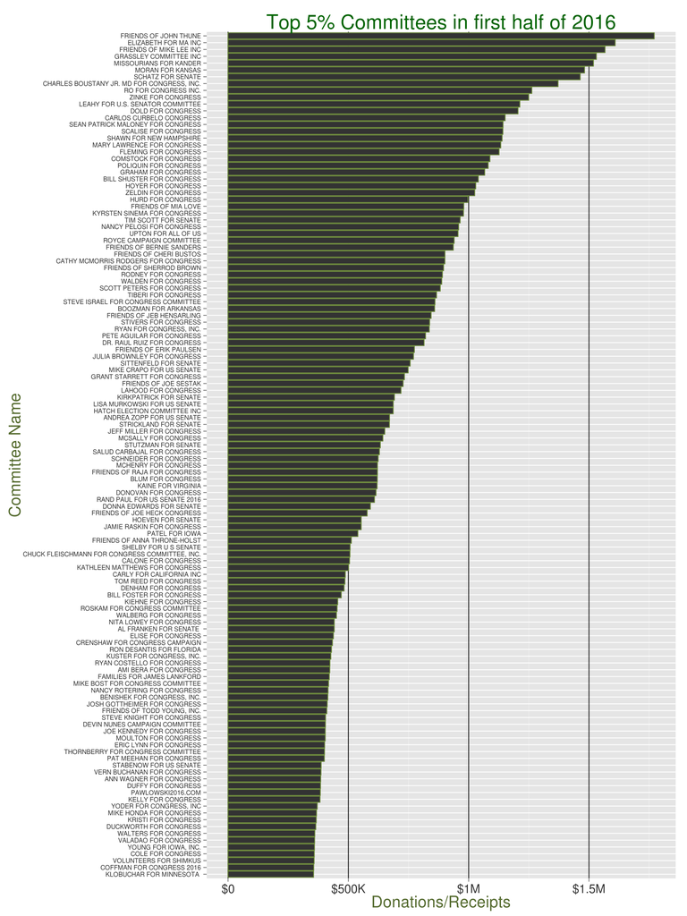

# 2 comparison of Income by Income Band

As a better analysis and illustration of the quesiton of what types of committees and what types of donations bring in the most money for the 2016 election so far, we can create bands of the committees where the committes are sorted by the amount of money they’ve brought in so far. in the analysis below these bands are: * 0-75% * 75-95% * 95-99% * top 1% As you can first see in the table:

As you can first see in the table, the bottom 75% of committes only bring in ~$21M with the maximum committe (the 75%) bringing in $86K. On the other end of the spectrumm the Top 1% also brought in approximately the same at $26m though their maximum contribution was $1M.

```
## Source: local data frame [5 x 4]
##
##   tot_recGrps    n maxIndivCommittee   tot_rec
## 1  bottom 75% 1118        $86,706.20  21090120
## 2  75% to 95%  676       $354,677.49 123734660
## 3  95% to 99%  135       $657,623.78  63397054
## 4      top 1%   34       $964,796.00  26050419
## 5          NA 1417             $0.00         0
```

graphing all 4 groups total income in a pie chart we can see that the 75-95% group is by far the largest total income producer (not the 95%-99% or the top 1% as common wisdom expects).

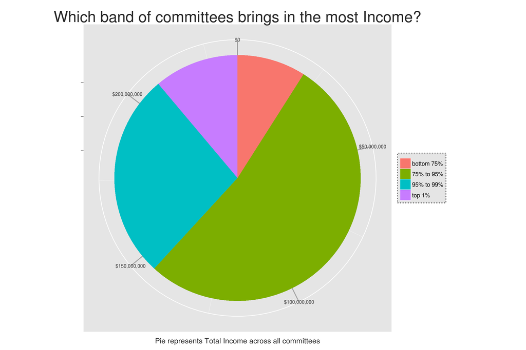

# 3 House versus Senate new campaign contributions by Income Band

Looking at which states produce the most income we can see in the following that California is the clear largest state for Committees. An interesting dynamic/correlation emerges from the Income Groupings though: The top 1% donate to the Senate much more than they do to the House.

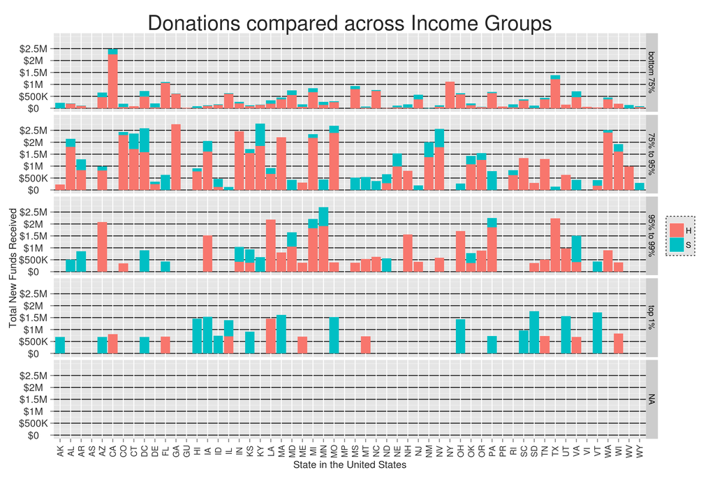

# Final Thoughts/Debrief:

1. Isssues
- Struggled because I needed/wanted more factors within which to analyze and possible work out some sort of stronger correlatio/model.
- Tried some larger ggpair and they bogged down my machine for over and hour before I killed it and wasn’t going to be able to read the plot anyway.
- had in mind to create even more complex combination graph with both datapoints (tot_rec & cas_on_han) with the facet by group but it wouldnt work. Pretty complex data arrangement.
2. Successes
- really geting closer to the grammer of graphics - can often remember words needed and most concepts without lookup. Just use google search now for tough stuff. Sometimes doing it in my dreams.
- learned some about the FEC and Campaign Committees. Especially interesting to me to debunk the thought that there are only a few really large PACs and that’s destroying US Democracy.
3. Next Steps:
- rerun the analysis at end of year and again this time next year.
- more research on the committees and what is and isn’t included in this data. It snow unclear to me which of these are so called superpacs.